# Statistical Learning

Last updated on 2017-03-06

## **Lec10 - Wed 3/8**: Splines

## What are splines?

Piecewise polynomials with smoothness constraints.

## **Lec08 - Fri 3/3**: Pseudocode for Cross-Validation

## `intro_splines.R` Solutions

Copy this at the end of `intro_splines.R` from previous lecture:

```r
# SOLUTIONS:
# 1. Note: Anything define in the ggplot() command trickles down to all the sub
# geoms. If you want to use data/aes() specific to only one particular geom,
# you define it inside:
ggplot(data=NULL, aes(x=x)) +
  # What we're given - the obs y:
  geom_point(data=real_life_augmented, aes(y=y)) +
  # What we won't typically know, but here we pretend to - the f(x) i.e. the signal:
  geom_line(data=simulated, aes(y=f), col="red", size=1) +
  # Our guess at f(x), i.e. f_hat(x) - our fitted/predicted values:
  geom_line(data=real_life_augmented, aes(y=.fitted), col="blue", size=1)

# 2. Let's toy around with df. In particular df=2, 10, 50, 99
real_life_augmented <- smooth.spline(real_life$x, real_life$y, df=50) %>%
  augment() %>%
  tbl_df()
ggplot(data=NULL, aes(x=x)) +
  geom_point(data=real_life_augmented, aes(y=y)) +
  geom_line(data=real_life_augmented, aes(y=.fitted), col="blue", size=1) +
  geom_line(data=simulated, aes(y=f), col="red", size=1)
```

## What does `df` do?

- See [handout](https://rudeboybert.github.io/MATH218/assets/splines/splines.pdf).
- If you're curious, see [source code](https://github.com/rudeboybert/MATH218/blob/gh-pages/assets/splines/intro_splines_2.R).

## **Lec07 - Wed 3/1**: Regression Part III

## Recall

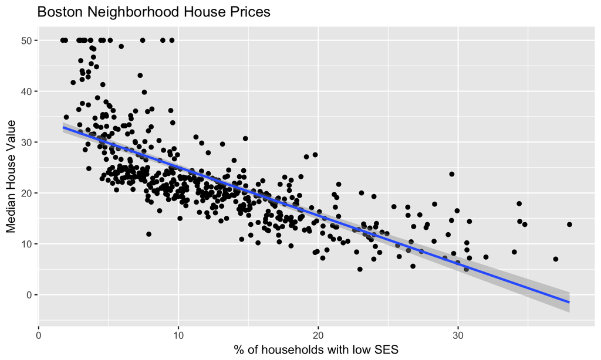

## Solutions

To `Chapter3_Lab.Rmd` from last lecture (better viewed from HTML document):

```r
# Load packages:
library(tidyverse)
library(MASS)
library(ISLR)
library(broom)

# Fit model. Boston would be the training data in a Kaggle competition.
# i.e. we have the outcome variable median house value
model_SL <- lm(medv~lstat, data=Boston)

# new_values would be the test data in a Kaggle competition
# i.e. we don't have the outcome variable
new_values <- data_frame(lstat=c(5,10,15))

# This is the MSE using the Boston training data:
augment(model_SL) %>%
  summarise(MSE=mean((medv-.fitted)^2))
# Or equivalently
augment(model_SL) %>%
  summarise(MSE=mean((.resid)^2))

# This value does not exist, b/c we don't have the real y, so we can't compute
# the residuals:
augment(model_SL, newdata = new_values) %>%
  summarise(MSE=mean((.resid)^2))
```

## Full Model

```r
# Fit model
model_full <- lm(medv~crim+zn+indus+chas+nox+rm+age+dis+rad+tax+ptratio+black+lstat, data=Boston)
# See coefficients
tidy(model_full)

# This is the MSE using the Boston training data:
# Or equivalently
augment(model_full) %>%
  summarise(MSE=mean((.resid)^2))
```

## Polynomial Model

```r
# Fit model
model_polynomial <-
  lm(medv~
       crim+zn+indus+chas+nox+rm+age+dis+rad+tax+ptratio+black+lstat+
       I(crim^2)+I(zn^2)+I(indus^2)+I(chas^2)+I(nox^2)+I(rm^2)+I(age^2)+I(dis^2)+I(rad^2)+I(tax^2)+I(ptratio^2)+I(black^2)+I(lstat^2),
     data=Boston)
# See coefficients
tidy(model_polynomial)

# This is the MSE using the Boston training data:
# Or equivalently
augment(model_polynomial) %>%
  summarise(MSE=mean((.resid)^2))
```

## **Lec06 - Mon 2/27**: Regression Part II

## Regression in R

Today we do the following to a simple linear regression in R

1. Fit the model \(\widehat{f}\)
2. Explore the fit
3. Use the fitted model to make predictions

## `broom` Package

As per the [tidy tools manifesto](https://cran.r-project.org/web/packages/tidyverse/vignettes/manifesto.html), we introduce the `broom` package:

- broom: let's tidy up a bit
- [GitHub source code](https://github.com/tidyverse/broom)

## **Lec05 - Fri 2/24**: Regression

## Names

Compare:

- Col Archibald Gracie IV
- Patrick O'Keefe

## Example 1 Regression for Explanation

From biology/medicine. Let

- \(Y\) = Blood-pressure
- \(X\) = Dosage of blood-pressure medicine (in ml)
- \(Y = \beta_0 + \beta_1 X\)
- **Intepretation of \(\beta_1\)**: For each additional ml increase in dosage, there is an on average (associated) effect of \(\beta_1\) units on blood-pressure.

## Example 2 Regression for Explanation

From economics/sociology. Let

- \(Y\) = Annual income
- \(X\) = # of years of schooling
- \(Y = \beta_0 + \beta_1 X\)
- **Intepretation of \(\beta_1\)**: For each additional year of schooling, there is an on average (associated) effect of \(\beta_1\) dollars on annual income.

## **Lec04 - Wed 2/22**: Intro to Cross-Validation

## Validation Set

Fig 5.1 p.177:

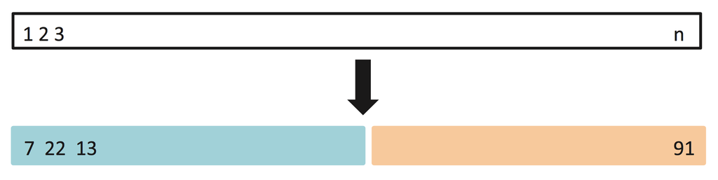

## LOOCV

Fig 5.3 p.179: Leave-One-Out Cross-Validation

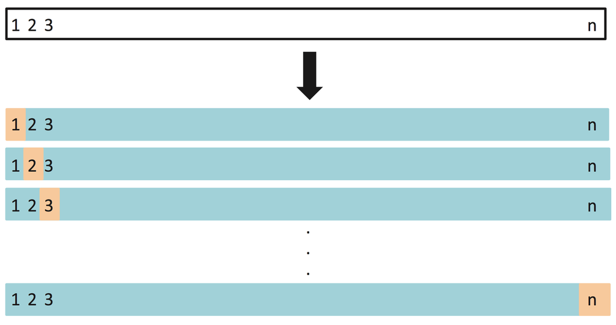

## k-Fold CV

Fig 5.5 p.181: \(k=5\) Fold CV

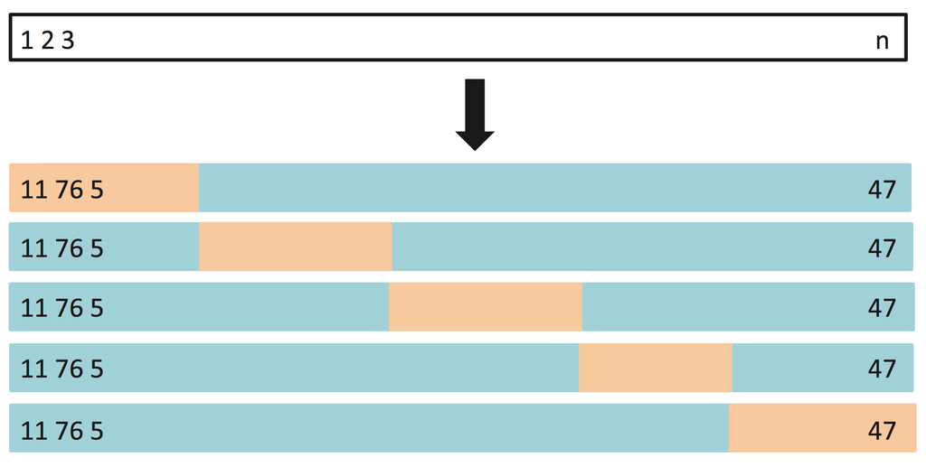

## Course for Next Few Lectures

Formalize what we mean by:

- **Model**: Relates predictors to outcomes. \(Y = f(\vec{X})\). Chapter [2, 2.1.3]
- **Score**: We want to minimize the mean squared error. Chapter 2.2

## Example: Data

Fig 2.2 p.17:

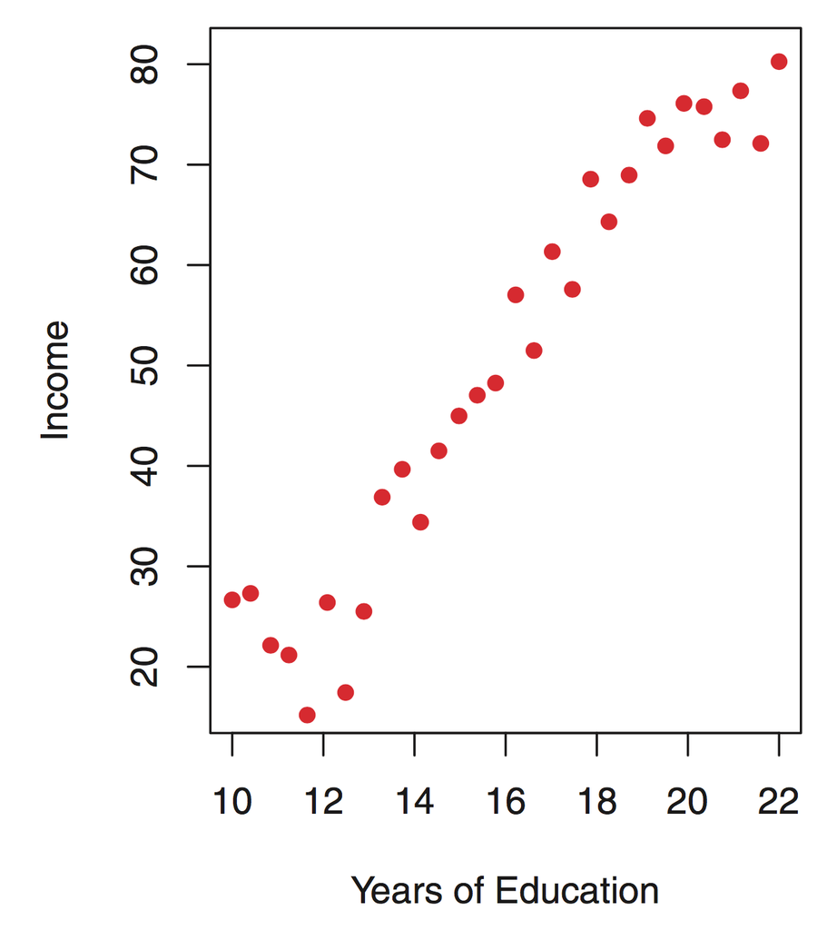

## Example: Model

Fig 2.2 p.17:

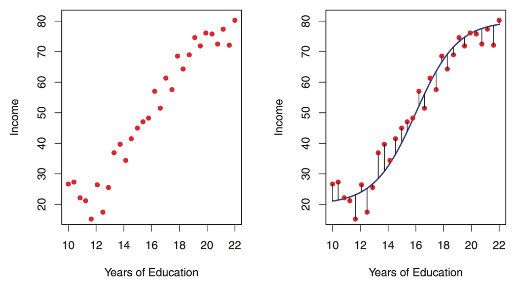

## **Lec03 - Mon 2/20**: Resampling for Prediction

## Score

- We submitted the following model to Kaggle: Predict `Survived <- ifelse(Sex == "female, 1, 0)`
- We got a [score](https://www.kaggle.com/c/titanic/leaderboard) (in this case "Categorization Accuracy" AKA proportion correct) of 0.76555.

\[Score = \frac{1}{n}\sum_{i=1}^{n}I(y_i = \widehat{y}_i)\] where

- \(I(y_i = \widehat{y}_i) = 1\) if \(y_i = \widehat{y}_i\)
- \(I(y_i = \widehat{y}_i) = 0\) if \(y_i \neq \widehat{y}_i\)

## Titanic Data

- Kaggle split the original complete passenger data into
  - `train` data (891 rows): used by you to train model
  - `test` data (418 rows): used by Kaggle to evaluate/score/validate model
- However, the [Evaluation](https://www.kaggle.com/c/titanic#evaluation) indicates they further randomly split into
  - 50% (209 rows): used by Kaggle compute your leaderboard score
  - 50% (209 rows): used by Kaggle **only at the end** to determine the ultimate winner
- This was done to prevent "overfitting" to the leaderboard: i.e. trying to game the leaderboard

## Question of the Day

- Kaggle limits to 10 entries per day i.e. 10 score computations
- What if we want to train models and compute scores for ourselves more often?
- However, we need true outcomes \(y_i\) to compute the score, which `test` doesn't have

## Solution

- Create `pseudo-train` and `pseudo-test` sets via **resampling** from `train`
- Compute pseudo-scores by applying your model to `pseudo-test`

## Resampling

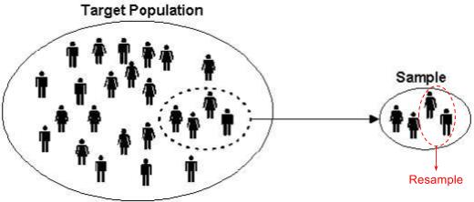

## Example

Create disjoint `pseudo_train` and `pseudo_test` data sets using `dplyr::anti_join`

```r
library(tidyverse)
# You may need to change your directory path:
train <- readr::read_csv("assets/Titanic/train.csv")

pseudo_train <- train %>%
  sample_frac(0.8)
pseudo_test <- train %>%
  anti_join(pseudo_train, by="PassengerId")
```

See RStudio Menu Bar -> Help -> Cheatsheets -> Data Manipulation.

## Resampling

Compute your pseudo-score

```r
pseudo_test %>%
  # Create new column of predictions:
  mutate(Survived_predicted = ifelse(Sex == "female", 1, 0)) %>%
  # Compute score:
  summarize(Score = mean(Survived == Survived_predicted))
```

```
## # A tibble: 1 × 1
##       Score
##       <dbl>
## 1 0.7865169
```

Compare this to Kaggle score of 0.76555. Why are they different?

## Resampling

- They are different b/c of sampling variability. Both at sampling and resampling stages!
- Let's repeat the above 10 times and get 10 pseudo-scores:

```
##  [1] 0.764 0.820 0.787 0.809 0.770 0.781 0.837 0.747 0.781 0.719
```

In this case, we have variability due to the resampling. The average of the 10 scores is 0.781

## **Lec02 - Wed 2/15**: Toolbox

## Toolbox

1. `R`: `tidyverse` and the pipe operator `%>%`
2. DataCamp
3. Kaggle

## Tool 1: `tidyverse`

`tidyverse` is a set of packages that work in harmony because they share common data representations and API design.

```r
install.packages("tidyverse")
library(tidyverse)
```

Read more on [RStudio's Blog](https://blog.rstudio.org/2016/09/15/tidyverse-1-0-0/).

## `tidyverse` Core Packages

These get loaded when you run `library(tidyverse)`

- `ggplot2` for data visualisation.
- `dplyr` for data manipulation.
- `tidyr` for data tidying.
- `readr` for data import.
- `purrr` for functional programming.
- `tibble` for tibbles, a modern re-imagining of data frames.

## `tidyverse` Non-Core Packages

These get installed with `tidyverse`

- `hms` for times.
- `stringr` for strings.
- `lubridate` for date/times.
- `forcats` for factors.

## `tidyverse` Data Import Packages

These get installed with `tidyverse`

- `DBI` for databases.
- `haven` for SPSS, SAS and Stata files.
- `httr` for web apis.
- `jsonlite` for JSON.
- `readxl` for .xls and .xlsx files.
- `rvest` for web scraping.
- `xml2` for XML.

## `tidyverse` Modelling Packages

These get installed with `tidyverse`

- `modelr` for simple modelling within a pipeline
- `broom` for turning models into tidy data

## Tool 2: DataCamp

- Browser-based interactive tool for learning R/python
- Interface is like RStudio: wrapper around R console
- You all have access to [ALL courses](https://www.datacamp.com/courses/) for free for the semester!

## DataCamp

If you are new to…

- `ggplot2`: Package for Data Visualization, do Data Visualization with ggplot2 [(Part 1)](https://www.datacamp.com/courses/data-visualization-with-ggplot2-1), [(Part 2)](https://www.datacamp.com/courses/data-visualization-with-ggplot2-2), and [(Part 3)](https://www.datacamp.com/courses/data-visualization-with-ggplot2-part-3)
- `dplyr`: Package for Data Manipulation, do [Data Manipulation in R with dplyr](https://www.datacamp.com/courses/dplyr-data-manipulation-r-tutorial) and [Joining Data in R with dplyr](https://www.datacamp.com/courses/joining-data-in-r-with-dplyr).
- R Markdown: Creating reproducible reports do [Reporting with R Markdown](https://www.datacamp.com/courses/reporting-with-r-markdown)

## Tool 3: Kaggle

- Baby's first Kaggle competition entry!
- Tutorial on their most popular competition for beginners [Titanic: Machine Learning from Disaster](https://www.kaggle.com/c/titanic).

## Titanic Data

For \(i=1,\ldots,n\) passengers

- ID variable: `PassengerId`
- Outcome variable \(y_i\): `Survived` (binary)
- 10 Predictors/covariates \(\vec{X}_i\) i.e. information about the passenger: `Pclass`, `Name`, `Sex`, `Age`, `SibSp`, `Parch`, `Ticket`, `Fare`, `Cabin`, `Embarked`.

## Models for Predicting Survival:

Naïve models: Use no information about the passenger, i.e. no covariates

1. Everyone dies: Predict
   - `Survived == 0`
2. Everyone lives: Predict
   - `Survived == 1`
3. Flip a weighted coin. Predict
   - `Survived == 1` with probability \(p\)
   - `Survived == 0` with probability \(1-p\)

## Models for Predicting Survival:

- Instead, let's use some information about the passengers: `Sex`?
- Our model: Predict:
  - `Survived == 1` if `Sex == "female"`
  - `Survived == 0` if `Sex == "male"`

## Outline of Competition

Chalk talk i.e. see your lecture notes.

## Titanic Data

Load CSV's into R:

```r
library(tidyverse)
gender_submission <- readr::read_csv("assets/Titanic/gender_submission.csv")
test <- readr::read_csv("assets/Titanic/test.csv")
train <- readr::read_csv("assets/Titanic/train.csv")
```

- You may need to change your directory path.
- `readr::` just indicates the function is from the `readr` package. Use for disambiguation.

## Training Set

The binary outcome varible `Survived` is included.

```r
glimpse(train)
```

```
## Observations: 891
## Variables: 12
## $ PassengerId <int> 1, 2, 3, 4, 5, 6, 7, 8, 9, 10, 11, 12, 13, 14, 15,...
## $ Survived    <int> 0, 1, 1, 1, 0, 0, 0, 0, 1, 1, 1, 1, 0, 0, 0, 1, 0,...
## $ Pclass      <int> 3, 1, 3, 1, 3, 3, 1, 3, 3, 2, 3, 1, 3, 3, 3, 2, 3,...
## $ Name        <chr> "Braund, Mr. Owen Harris", "Cumings, Mrs. John Bra...
## $ Sex         <chr> "male", "female", "female", "female", "male", "mal...
## $ Age         <dbl> 22, 38, 26, 35, 35, NA, 54, 2, 27, 14, 4, 58, 20, ...
## $ SibSp       <int> 1, 1, 0, 1, 0, 0, 0, 3, 0, 1, 1, 0, 0, 1, 0, 0, 4,...
## $ Parch       <int> 0, 0, 0, 0, 0, 0, 0, 1, 2, 0, 1, 0, 0, 5, 0, 0, 1,...
## $ Ticket      <chr> "A/5 21171", "PC 17599", "STON/O2. 3101282", "1138...
## $ Fare        <dbl> 7.2500, 71.2833, 7.9250, 53.1000, 8.0500, 8.4583, ...
## $ Cabin       <chr> NA, "C85", NA, "C123", NA, NA, "E46", NA, NA, NA, ...
## $ Embarked    <chr> "S", "C", "S", "S", "S", "Q", "S", "S", "S", "C", ...
```

## Test Set

`Survived` is now **NOT** included. There are 418 rows (passengers) you need to predict.

```r
glimpse(test)
```

```
## Observations: 418
## Variables: 11
## $ PassengerId <int> 892, 893, 894, 895, 896, 897, 898, 899, 900, 901, ...
## $ Pclass      <int> 3, 3, 2, 3, 3, 3, 3, 2, 3, 3, 3, 1, 1, 2, 1, 2, 2,...
## $ Name        <chr> "Kelly, Mr. James", "Wilkes, Mrs. James (Ellen Nee...
## $ Sex         <chr> "male", "female", "male", "male", "female", "male"...
## $ Age         <dbl> 34.5, 47.0, 62.0, 27.0, 22.0, 14.0, 30.0, 26.0, 18...
## $ SibSp       <int> 0, 1, 0, 0, 1, 0, 0, 1, 0, 2, 0, 0, 1, 1, 1, 1, 0,...
## $ Parch       <int> 0, 0, 0, 0, 1, 0, 0, 1, 0, 0, 0, 0, 0, 0, 0, 0, 0,...
## $ Ticket      <chr> "330911", "363272", "240276", "315154", "3101298",...
## $ Fare        <dbl> 7.8292, 7.0000, 9.6875, 8.6625, 12.2875, 9.2250, 7...
## $ Cabin       <chr> NA, NA, NA, NA, NA, NA, NA, NA, NA, NA, NA, NA, "B...
## $ Embarked    <chr> "Q", "S", "Q", "S", "S", "S", "Q", "S", "C", "S", ...
```

## Submission Example

This is what you submit: 418 rows with

- the ID variable `PassengerId`
- your **predicted** outcome variable `Survived`

```r
glimpse(gender_submission)
```

```
## Observations: 418
## Variables: 2
## $ PassengerId <int> 892, 893, 894, 895, 896, 897, 898, 899, 900, 901, ...
## $ Survived    <int> 0, 1, 0, 0, 1, 0, 1, 0, 1, 0, 0, 0, 1, 0, 1, 1, 0,...
```

## Submission Example

You can write to CSV via:

```r
gender_submission %>% readr::write_csv("assets/Titanic/submission.csv")
```

## Submission Example

After submitting to Kaggle, you can see your ranking.

## **Lec01 - Mon 2/13**: Introduction

## What is statistical/machine learning?

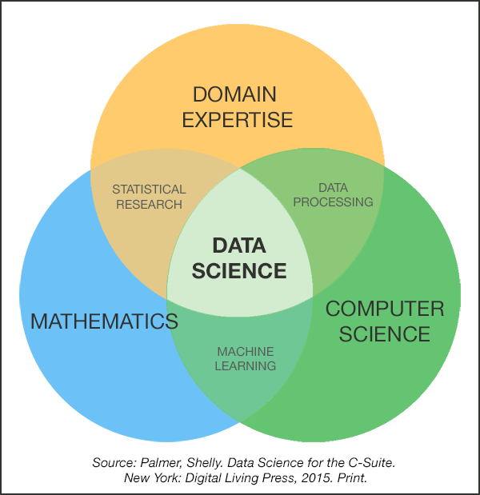

## What is statistical/machine learning?

- In Feb 2016, I agonized over title of course: "Statistical Learning" vs "Machine Learning"
- In Summer 2016: Ben Baumer at Smith posed:
- *"Instead of obsessing over Venn diagrams of what topics are within the domains of which disciplines, I ask instead…"*
- *"… What if we blew up math, stats, CS, and all their legacies and started over? What would this field look like?"*
- New moniker: Machine learning… taught from a statistician's perspective

## Definitions

- Arthur Samuel (1959): Machine learning is the subfield of computer science that gives computers the ability to learn without being explicitly programmed.
- Me: Prediction

## Examples:

- [Self-Driving Vehicles](https://www.wired.com/2016/10/ubers-self-driving-truck-makes-first-delivery-50000-beers/)
- Netflix recommendations
- Simple linear regression

## Background

- In the past, lots and lots of mathmatical science pre-requisites: algorithms, probability, linear algebra, etc.
- Brought to you from folks at Stanford in 2001:

[figure not shown]

## Unchartered Territory

- New model: flatter pre-requisite structure. That means we'll have a few digressions for probability, linear algebra, etc.
- Brought to you from folks at Stanford (again) in 2013:

[figure not shown]

## Unchartered Territory

- Book is still much like beta version of software:
  - New, exciting, and cutting edge but…
  - Lots bugs
- Battle tested with:

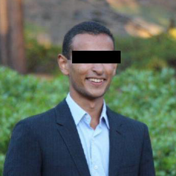

- Smith College SDS Initiative https://github.com/SmithCollege-SDS/tidy-islr

## Toolbox

[figure not shown]

- [R vs Python](https://www.google.com/search?q=r+vs+python). A hammer vs a screwdriver
- Argument for R: Wickham's [Tidy tools manifesto](https://cran.r-project.org/web/packages/tidyverse/vignettes/manifesto.html)
  - Reuse existing data structures: Consistency across packages e.g. `ggplot2`, `dplyr`, `modelr`
  - Design for humans: Bottleneck in most data analysis is thinking time, not computing time. i.e. avoid **premature optimization**

## Cornerstone of Course

Final Project: Kaggle (rhymes with haggle) [competition](https://www.kaggle.com/competitions).

## Sampling

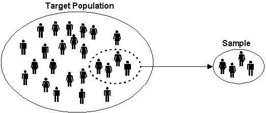

## Resampling

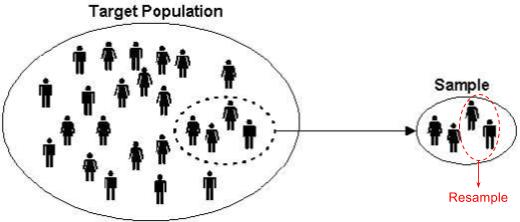